# Prévision de Données Temporelles

2026-03-08

## Série 1 — Abonnés Netflix

## Présentation des données

- **Source** : Kaggle / GitHub projet
- **Variable** : Nombre d’abonnés (millions)
- **Période** : Trimestrielle
- **Caractéristique** : Série avec **tendance forte**, **sans saisonnalité** marquée

## Visualisation brute de la série

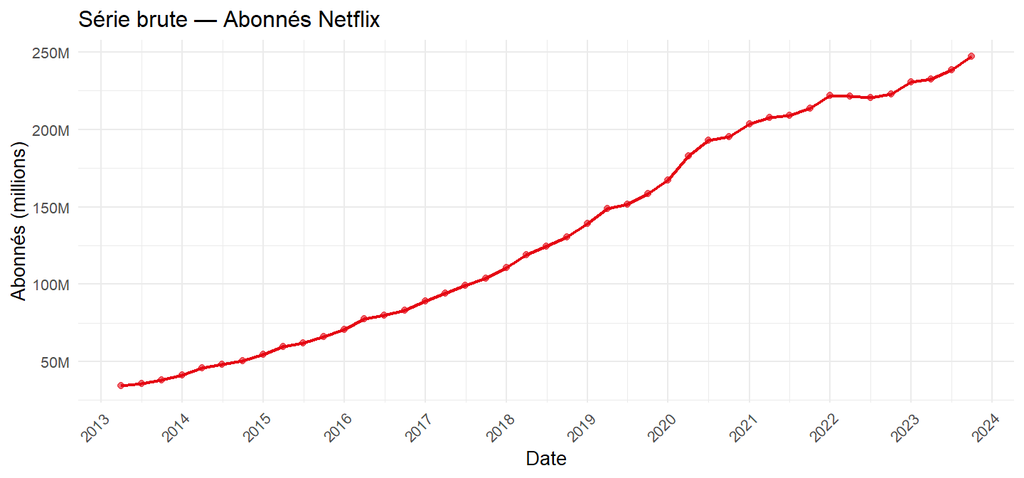

Nombre d’abonnés Netflix — série brute

## Modèle 1 — Moyennes sur le passé

La méthode des **moyennes sur le passé** prédit chaque valeur future par la moyenne de **toutes les observations précédentes**. C’est la référence naïve.

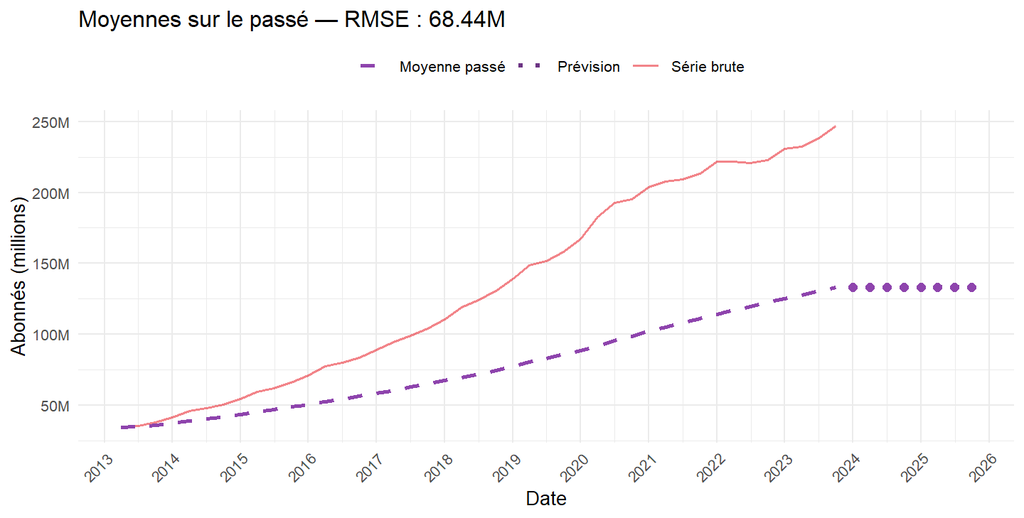

Prévision par moyennes sur le passé — Netflix

La moyenne sur le passé **sous-estime** fortement la croissance : elle ne capte pas la tendance haussière, ce qui donne un RMSE élevé.

## Modèle 2 — Lissage exponentiel double (Holt)

Le **lissage de Holt** lisse simultanément le **niveau** et la **tendance**, ce qui le rend adapté à une série sans saisonnalité mais à croissance soutenue.

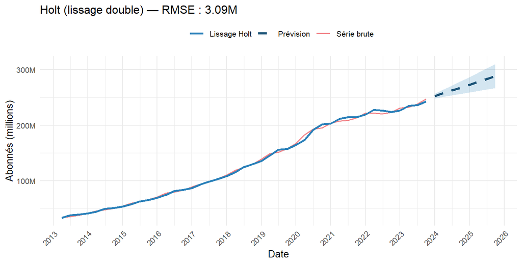

Lissage exponentiel double Holt — Netflix avec prévisions

## Comparaison des modèles — Netflix

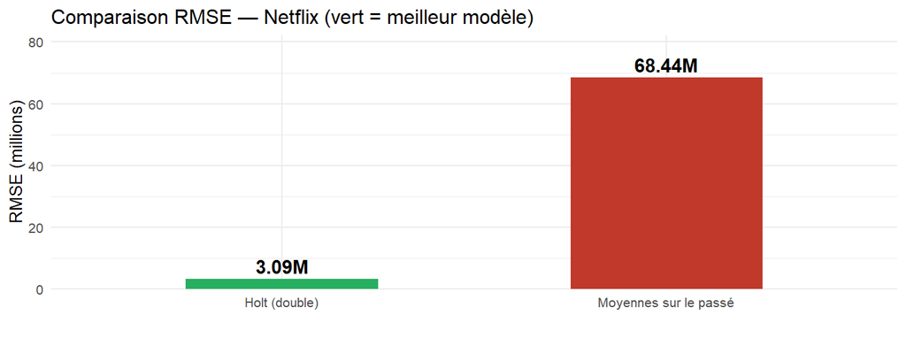

Comparaison RMSE — Netflix

Le **lissage de Holt** est retenu : son RMSE est nettement inférieur car il suit la tendance croissante, contrairement à la méthode naïve qui converge vers une valeur fixe.

## Analyse des résidus — Holt

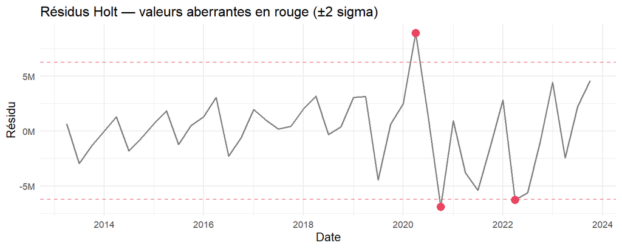

Résidus du lissage Holt — Netflix

## Visualisation brute de la série

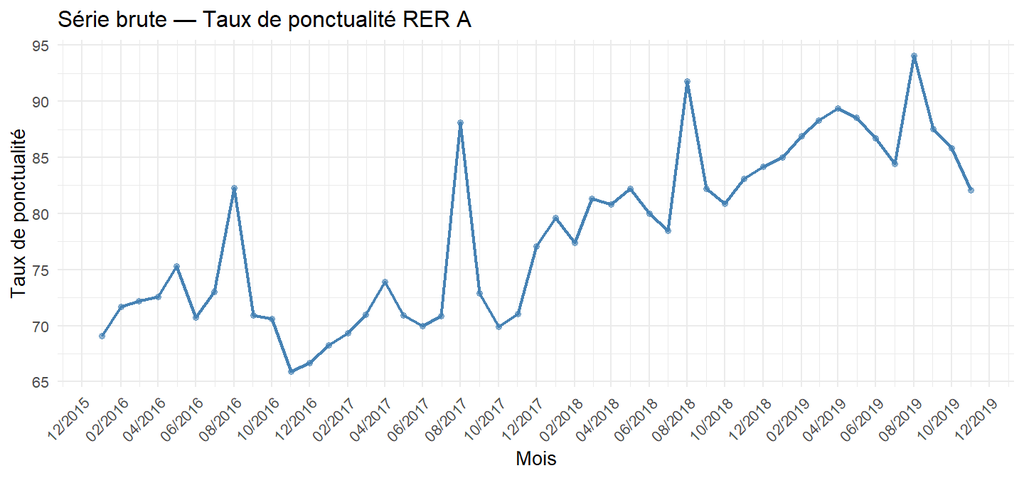

Taux de ponctualité mensuel brut — RER A (2016–2020)

## Décomposition additive (Moyennes Mobiles)

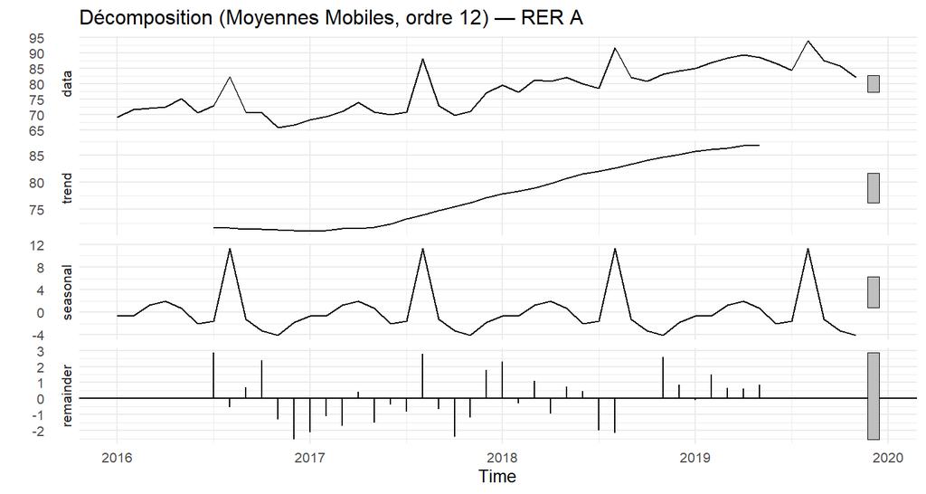

Décomposition additive — RER A

## Coefficients saisonniers

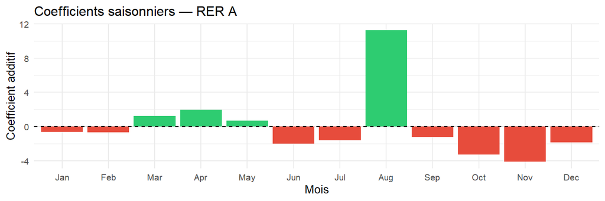

Coefficients saisonniers mensuels — RER A

## Série CVS

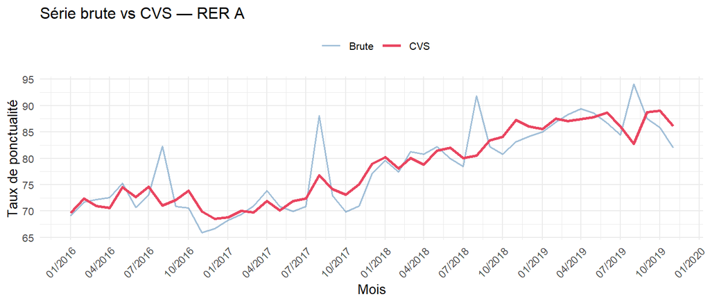

Série brute vs Corrigée des variations saisonnières

## Analyse des résidus

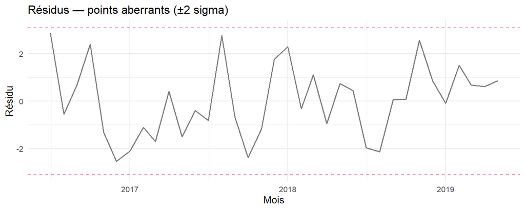

Résidus — valeurs mal ajustées en rouge (±2 sigma)

## Modèle 1 — Prévision par Moyennes Mobiles (k=12)

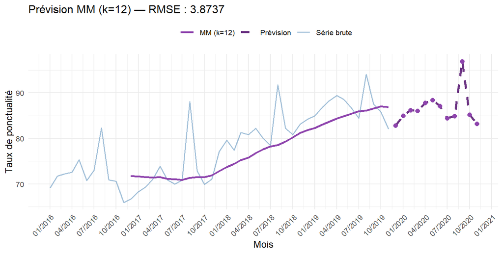

Prévision par moyennes mobiles (k=12) — RER A

## Modèle 2 — Lissage exponentiel triple (Holt-Winters)

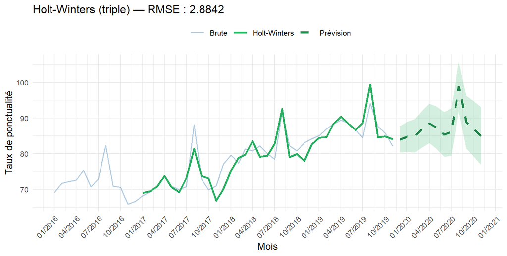

Holt-Winters (lissage triple) — RER A avec prévisions

## Comparaison des modèles — RER A

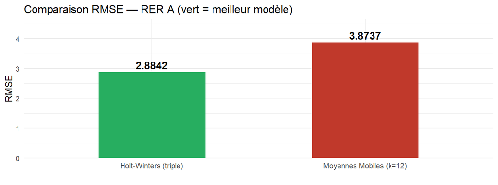

Comparaison RMSE — RER A

**Holt-Winters** est retenu : il modélise dynamiquement tendance et saisonnalité, là où la moyenne mobile applique un poids uniforme sans s’adapter.

## Conclusion Générale

[output not shown]

Dans les deux cas, le **RMSE** valide le choix du modèle le mieux adapté à la structure de la série : LED pour une tendance pure, LET dès qu’une saisonnalité est présente.